# Sports Analytics- IPL Data

Mahendhar Saratha

### 1. Project Introduction

In this project, I examine IPL cricket match data from 2008 to 2022. I utilize statistical and machine learning techniques to predict match outcomes based on various factors, including runs scored, balls faced, highest scores, Wickets taken , batting strike rates, and batting averages. The project workflow involves multiple stages: loading and cleaning the data, performing exploratory data analysis (EDA), and developing and evaluating predictive models. The models implemented include logistic regression, simple linear regression, and multiple linear regression, with the goal of identifying key predictors and building robust models to improve our understanding and prediction of match outcomes.

### 2. Loading Libraries

```r
# Load required libraries
library(dplyr)
library(ggplot2)
library(dplyr)
library(skimr)
library(tidyr)
library(tidymodels)
library(tidyverse)
library(tidytext)
library(flextable)
library(caret)
library(naniar)
```

### 3. Loading Datasets

```r
# Load the datasets
matches <- read_csv('~/Regression/IPL_Matches_2008_2022.csv')
deliveries <- read_csv('~/Regression/IPL_Ball_by_Ball_2008_2022.csv')
```

```r
glimpse(deliveries)
```

```
## Rows: 225,954
## Columns: 17
## $ ID                <dbl> 1312200, 1312200, 1312200, 1312200, 1312200, 1312200…
## $ innings           <dbl> 1, 1, 1, 1, 1, 1, 1, 1, 1, 1, 1, 1, 1, 1, 1, 1, 1, 1…
## $ overs             <dbl> 0, 0, 0, 0, 0, 0, 1, 1, 1, 1, 1, 1, 2, 2, 2, 2, 2, 2…
## $ ballnumber        <dbl> 1, 2, 3, 4, 5, 6, 1, 2, 3, 4, 5, 6, 1, 2, 3, 4, 5, 6…
## $ batter            <chr> "YBK Jaiswal", "YBK Jaiswal", "JC Buttler", "YBK Jai…
## $ bowler            <chr> "Mohammed Shami", "Mohammed Shami", "Mohammed Shami"…
## $ `non-striker`     <chr> "JC Buttler", "JC Buttler", "YBK Jaiswal", "JC Buttl…
## $ extra_type        <chr> NA, "legbyes", NA, NA, NA, NA, NA, NA, NA, NA, NA, N…
## $ batsman_run       <dbl> 0, 0, 1, 0, 0, 0, 0, 0, 4, 0, 1, 0, 1, 0, 4, 0, 6, 3…
## $ extras_run        <dbl> 0, 1, 0, 0, 0, 0, 0, 0, 0, 0, 0, 0, 0, 0, 0, 0, 0, 0…
## $ total_run         <dbl> 0, 1, 1, 0, 0, 0, 0, 0, 4, 0, 1, 0, 1, 0, 4, 0, 6, 3…
## $ non_boundary      <dbl> 0, 0, 0, 0, 0, 0, 0, 0, 0, 0, 0, 0, 0, 0, 0, 0, 0, 0…
## $ isWicketDelivery  <dbl> 0, 0, 0, 0, 0, 0, 0, 0, 0, 0, 0, 0, 0, 0, 0, 0, 0, 0…
## $ player_out        <chr> NA, NA, NA, NA, NA, NA, NA, NA, NA, NA, NA, NA, NA, …
## $ kind              <chr> NA, NA, NA, NA, NA, NA, NA, NA, NA, NA, NA, NA, NA, …
## $ fielders_involved <chr> NA, NA, NA, NA, NA, NA, NA, NA, NA, NA, NA, NA, NA, …
## $ BattingTeam       <chr> "Rajasthan Royals", "Rajasthan Royals", "Rajasthan R…
```

#### Analysing Missing Values

Firstly, Analyzing messing values using skim() function from `skimr` package

Analyzing matches data

```r
skim_matches_data <- skim(matches)
print(skim_matches_data)
```

```
## ── Data Summary ────────────────────────
##                            Values
## Name                       matches
## Number of rows             950
## Number of columns          20
## _______________________
## Column type frequency:
##   character                17
##   Date                     1
##   numeric                  2
## ________________________
## Group variables            None
##
## ── Variable type: character ────────────────────────────────────────────────────
##    skim_variable   n_missing complete_rate min max empty n_unique whitespace
##  1 City                   51        0.946    4  14     0       33          0
##  2 Season                  0        1        4   7     0       15          0
##  3 MatchNumber             0        1        1  18     0       80          0
##  4 Team1                   0        1       12  27     0       18          0
##  5 Team2                   0        1       12  27     0       18          0
##  6 Venue                   0        1        8  52     0       49          0
##  7 TossWinner              0        1       12  27     0       18          0
##  8 TossDecision            0        1        3   5     0        2          0
##  9 SuperOver               4        0.996    1   1     0        2          0
## 10 WinningTeam             4        0.996   12  27     0       18          0
## 11 WonBy                   0        1        4   9     0        4          0
## 12 method                931        0.0200   3   3     0        1          0
## 13 Player_of_Match         4        0.996    5  17     0      262          0
## 14 Team1Players            0        1      129 171     0      932          0
## 15 Team2Players            0        1      129 174     0      937          0
## 16 Umpire1                 0        1        5  21     0       58          0
## 17 Umpire2                 0        1        5  21     0       60          0
##
## ── Variable type: Date ─────────────────────────────────────────────────────────
##   skim_variable n_missing complete_rate min        max        median
## 1 Date                  0             1 2008-04-18 2022-05-29 2015-04-20
##   n_unique
## 1      706
##
## ── Variable type: numeric ──────────────────────────────────────────────────────
##   skim_variable n_missing complete_rate     mean       sd     p0     p25    p50
## 1 ID                    0         1     830485.  337568.  335982 501261. 829738
## 2 Margin               18         0.981     17.1     21.6      1      6       8
##        p75    p100 hist
## 1 1175372. 1312200 ▆▃▃▃▇
## 2      19      146 ▇▁▁▁▁
```

There is missing data in some columns, but our focus for further analysis is on the WinningTeam column. The missing values correspond to drawn matches, so I will remove these rows to concentrate on a binary classification task (win/lose) using logistic regression.

```r
matches <- matches[!is.na(matches$WinningTeam), ]
```

Analyzing deliveries data

```r
skim_deliveries_data <- skim(deliveries)
print(skim_deliveries_data)
```

```
## ── Data Summary ────────────────────────
##                            Values
## Name                       deliveries
## Number of rows             225954
## Number of columns          17
## _______________________
## Column type frequency:
##   character                8
##   numeric                  9
## ________________________
## Group variables            None
##
## ── Variable type: character ────────────────────────────────────────────────────
##   skim_variable     n_missing complete_rate min max empty n_unique whitespace
## 1 batter                    0        1        5  23     0      605          0
## 2 bowler                    0        1        5  23     0      472          0
## 3 non-striker               0        1        5  23     0      595          0
## 4 extra_type           213905        0.0533   4   7     0        5          0
## 5 player_out           214803        0.0494   5  23     0      573          0
## 6 kind                 214803        0.0494   3  21     0       10          0
## 7 fielders_involved    217966        0.0354   5  23     0      535          0
## 8 BattingTeam               0        1       12  27     0       18          0
##
## ── Variable type: numeric ──────────────────────────────────────────────────────
##   skim_variable    n_missing complete_rate    mean           sd     p0    p25
## 1 ID                       0             1 8.32e+5 337954.      335982 501262
## 2 innings                  0             1 1.48e+0      0.503        1      1
## 3 overs                    0             1 9.19e+0      5.68         0      4
## 4 ballnumber               0             1 3.62e+0      1.81         1      2
## 5 batsman_run              0             1 1.24e+0      1.62         0      0
## 6 extras_run               0             1 6.69e-2      0.341        0      0
## 7 total_run                0             1 1.31e+0      1.61         0      0
## 8 non_boundary             0             1 9.29e-5      0.00964      0      0
## 9 isWicketDelivery         0             1 4.94e-2      0.217        0      0
##      p50     p75    p100 hist
## 1 829737 1178395 1312200 ▆▃▃▃▇
## 2      1       2       6 ▇▁▁▁▁
## 3      9      14      19 ▇▇▇▇▇
## 4      4       5      10 ▇▇▇▁▁
## 5      1       1       6 ▇▁▁▁▁
## 6      0       0       7 ▇▁▁▁▁
## 7      1       1       7 ▇▁▁▁▁
## 8      0       0       1 ▇▁▁▁▁
## 9      0       0       1 ▇▁▁▁▁
```

We have missing data in some columns in deliveries data as well, but we are not focusing on these for our analysis.

### 4. Data Preparation and cleaning

Calculating the total `Runs_Scored` and `Balls_Faced` for each batter, group the data by batter and summarize the total runs and balls faced. This will provide a summarized data frame with each batter’s total runs and balls faced for further analysis

```r
batter_stats <- deliveries |> group_by(batter) |>
  summarise(Runs_Scored = sum(batsman_run),Balls_Faced = n()) |>
  ungroup()
```

```r
head(batter_stats) |> flextable()
```

| batter | Runs_Scored | Balls_Faced |
| --- | --- | --- |
| A Ashish Reddy | 280 | 196 |
| A Badoni | 161 | 139 |
| A Chandila | 4 | 7 |
| A Chopra | 53 | 75 |
| A Choudhary | 25 | 20 |
| A Dananjaya | 4 | 5 |

Calculating the highest score for each batter, group the data by batter and find the maximum score for each one

```r
highest_score_tmp <- deliveries |>
  group_by(batter, ID) |>
  summarise(Innings_Runs = sum(batsman_run)) |>
  ungroup()


highest_score <- highest_score_tmp |> group_by(batter) |>
  summarise(Highest_Score = max(Innings_Runs)) |>
  ungroup()
```

```r
head(highest_score) |> flextable()
```

| batter | Highest_Score |
| --- | --- |
| A Ashish Reddy | 36 |
| A Badoni | 54 |
| A Chandila | 4 |
| A Chopra | 24 |
| A Choudhary | 15 |
| A Dananjaya | 4 |

Joining both datasets for the combined data

```r
batter_stats <- batter_stats |> left_join(highest_score, by = "batter")
head(batter_stats) |> flextable()
```

| batter | Runs_Scored | Balls_Faced | Highest_Score |
| --- | --- | --- | --- |
| A Ashish Reddy | 280 | 196 | 36 |
| A Badoni | 161 | 139 | 54 |
| A Chandila | 4 | 7 | 4 |
| A Chopra | 53 | 75 | 24 |
| A Choudhary | 25 | 20 | 15 |
| A Dananjaya | 4 | 5 | 4 |

Calculating Batting_Strike_Rate:

```r
batter_stats <- batter_stats |> mutate(Batting_Strike_Rate = (Runs_Scored / Balls_Faced) * 100)
```

```r
head(batter_stats |> select(batter,Runs_Scored,Balls_Faced,Batting_Strike_Rate)) |> flextable()
```

| batter | Runs_Scored | Balls_Faced | Batting_Strike_Rate |
| --- | --- | --- | --- |
| A Ashish Reddy | 280 | 196 | 142.85714 |
| A Badoni | 161 | 139 | 115.82734 |
| A Chandila | 4 | 7 | 57.14286 |
| A Chopra | 53 | 75 | 70.66667 |
| A Choudhary | 25 | 20 | 125.00000 |
| A Dananjaya | 4 | 5 | 80.00000 |

Calculating Not outs for the batsmen

```r
innings_not_outs <- deliveries |> group_by(batter) |>
  summarise(Innings = n_distinct(ID),
            Not_Outs = sum(is.na(player_out))) |>
  ungroup()
```

```r
head(innings_not_outs |> select(batter,Not_Outs)) |> flextable()
```

| batter | Not_Outs |
| --- | --- |
| A Ashish Reddy | 181 |
| A Badoni | 130 |
| A Chandila | 6 |
| A Chopra | 70 |
| A Choudhary | 18 |
| A Dananjaya | 5 |

Combining the data

```r
batter_stats <- batter_stats |> left_join(innings_not_outs, by = "batter")
```

Calculating the batting average involves using the total runs scored, the number of innings played, and the number of times the batter remained not out.

```r
batter_stats <- batter_stats |>
  mutate(Batting_Average = ifelse(Innings - Not_Outs > 0, Runs_Scored / (Innings - Not_Outs), 0))
```

```r
head(batter_stats |> select(batter,Runs_Scored,Balls_Faced,Innings,Not_Outs,Batting_Average)) |> flextable()
```

| batter | Runs_Scored | Balls_Faced | Innings | Not_Outs | Batting_Average |
| --- | --- | --- | --- | --- | --- |
| A Ashish Reddy | 280 | 196 | 23 | 181 | 0 |
| A Badoni | 161 | 139 | 11 | 130 | 0 |
| A Chandila | 4 | 7 | 2 | 6 | 0 |
| A Chopra | 53 | 75 | 6 | 70 | 0 |
| A Choudhary | 25 | 20 | 3 | 18 | 0 |
| A Dananjaya | 4 | 5 | 1 | 5 | 0 |

### 5. Exploratory Data Analysis

Exploratory Data Analysis (EDA) for matches Dataset

```r
# Summary statistics
summary(matches)
```

```
##        ID              City                Date               Season
##  Min.   : 335982   Length:946         Min.   :2008-04-18   Length:946
##  1st Qu.: 501260   Class :character   1st Qu.:2011-05-17   Class :character
##  Median : 829736   Mode  :character   Median :2015-04-19   Mode  :character
##  Mean   : 830467                      Mean   :2015-05-14
##  3rd Qu.:1175372                      3rd Qu.:2019-04-04
##  Max.   :1312200                      Max.   :2022-05-29
##
##  MatchNumber           Team1              Team2              Venue
##  Length:946         Length:946         Length:946         Length:946
##  Class :character   Class :character   Class :character   Class :character
##  Mode  :character   Mode  :character   Mode  :character   Mode  :character
##
##
##
##
##   TossWinner        TossDecision        SuperOver         WinningTeam
##  Length:946         Length:946         Length:946         Length:946
##  Class :character   Class :character   Class :character   Class :character
##  Mode  :character   Mode  :character   Mode  :character   Mode  :character
##
##
##
##
##     WonBy               Margin          method          Player_of_Match
##  Length:946         Min.   :  1.00   Length:946         Length:946
##  Class :character   1st Qu.:  6.00   Class :character   Class :character
##  Mode  :character   Median :  8.00   Mode  :character   Mode  :character
##                     Mean   : 17.06
##                     3rd Qu.: 19.00
##                     Max.   :146.00
##                     NA's   :14
##  Team1Players       Team2Players         Umpire1            Umpire2
##  Length:946         Length:946         Length:946         Length:946
##  Class :character   Class :character   Class :character   Class :character
##  Mode  :character   Mode  :character   Mode  :character   Mode  :character
##
##
##
##
```

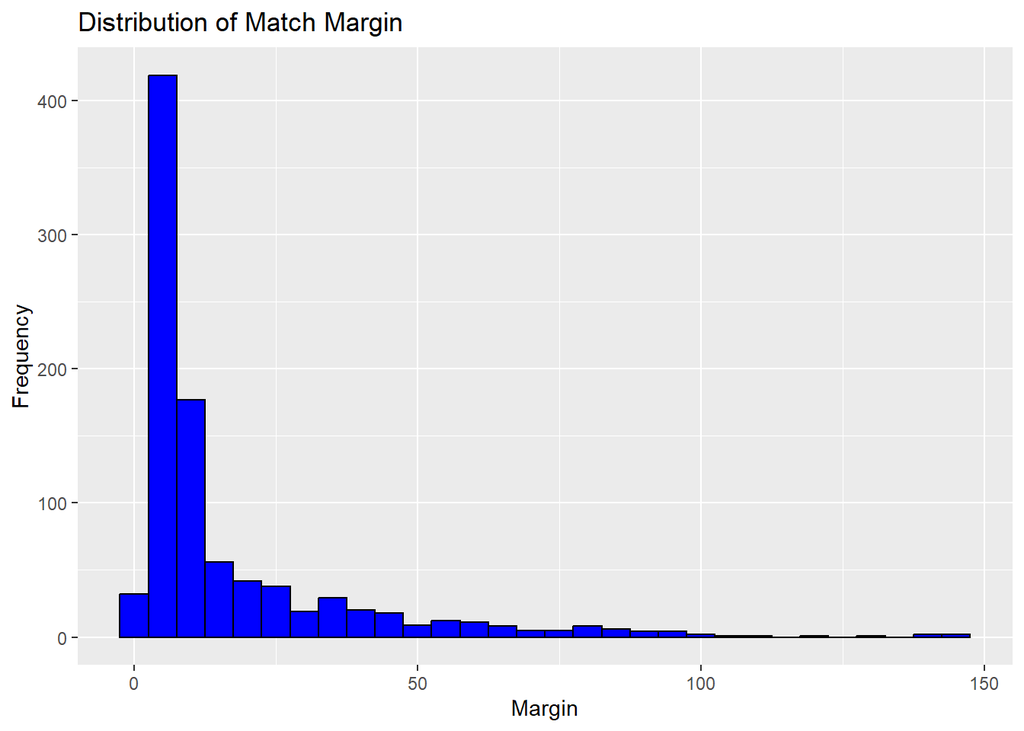

```r
# Distribution of numerical variables
ggplot(matches, aes(x = Margin)) +
  geom_histogram(binwidth = 5, fill = 'blue', color = 'black') +
  labs(title = 'Distribution of Match Margin', x = 'Margin', y = 'Frequency')
```

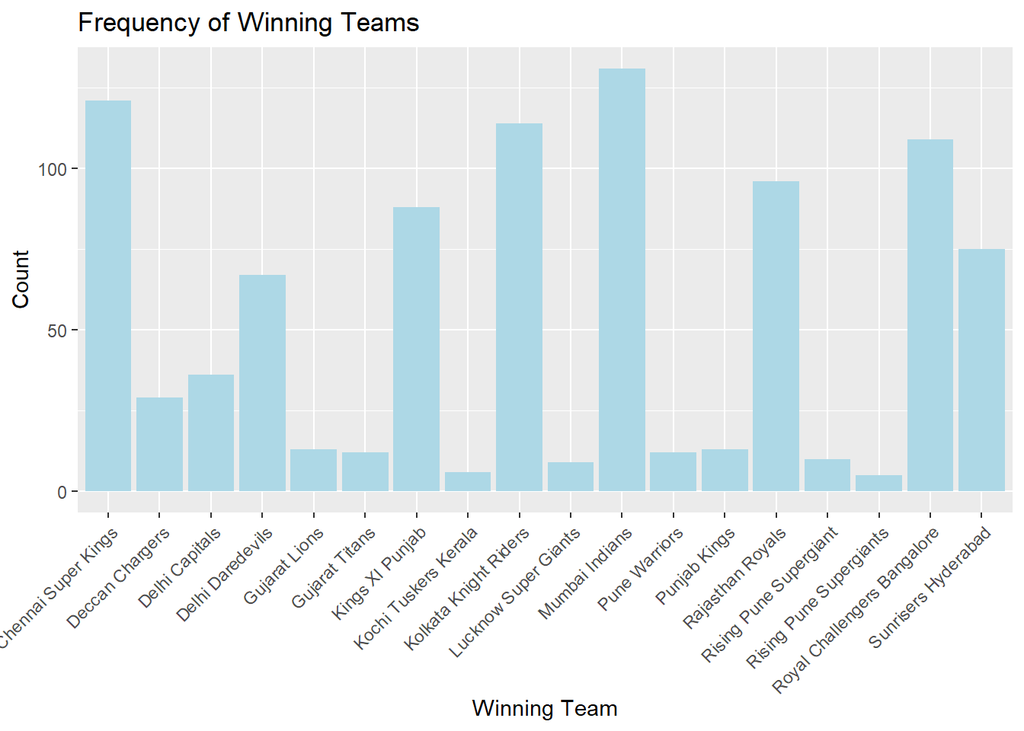

```r
# Distribution of categorical variables
ggplot(matches, aes(x = WinningTeam)) +
  geom_bar(fill = 'lightblue') +
  labs(title = 'Frequency of Winning Teams', x = 'Winning Team', y = 'Count')+
  theme(axis.text.x = element_text(angle = 45, hjust = 1))
```

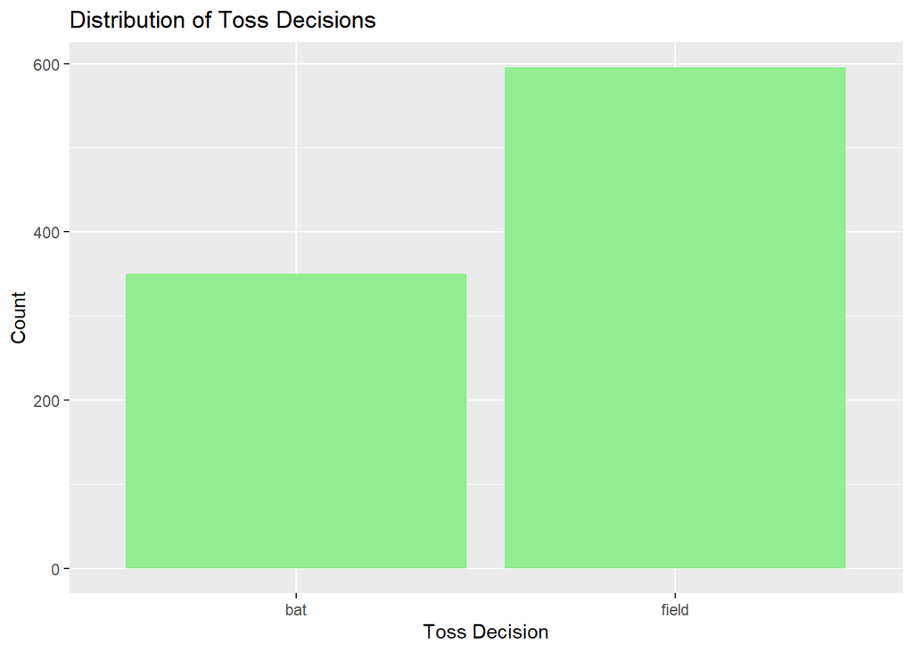

```r
# Distribution of toss decisions
ggplot(matches, aes(x = TossDecision)) +
  geom_bar(fill = 'lightgreen') +
  labs(title = 'Distribution of Toss Decisions', x = 'Toss Decision', y = 'Count')
```

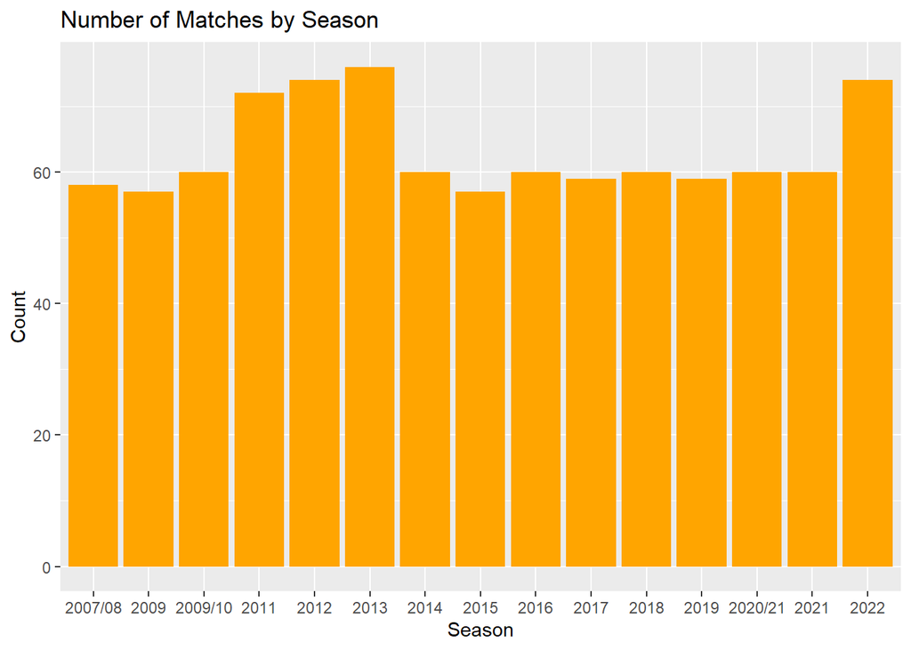

```r
# Number of matches by season
ggplot(matches, aes(x = Season)) +
  geom_bar(fill = 'orange') +
  labs(title = 'Number of Matches by Season', x = 'Season', y = 'Count')
```

`Distribution of Match Margin:` The histogram shows that most IPL matches have small to moderate win margins, indicating competitive games. However, a few matches have very large margins, suggesting occasional one-sided games.

`Frequency of Winning Teams:` The bar chart reveals that certain teams, like Mumbai Indians and Chennai Super Kings, have a higher frequency of wins, highlighting their dominance in the IPL.

`Distribution of Toss Decisions:` The bar chart indicates that teams generally prefer to field first after winning the toss, suggesting a strategic advantage in chasing a target.

`Proportion of Match Wins by Toss Winner:` The bar chart shows that teams winning the toss have a slightly higher proportion of match wins, implying a marginal advantage of winning the toss.

Exploratory Data Analysis (EDA) for deliveries Dataset

finding missing values in matches dataset

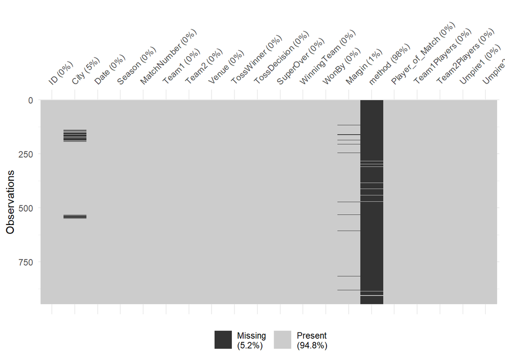

```r
vis_miss(matches)
```

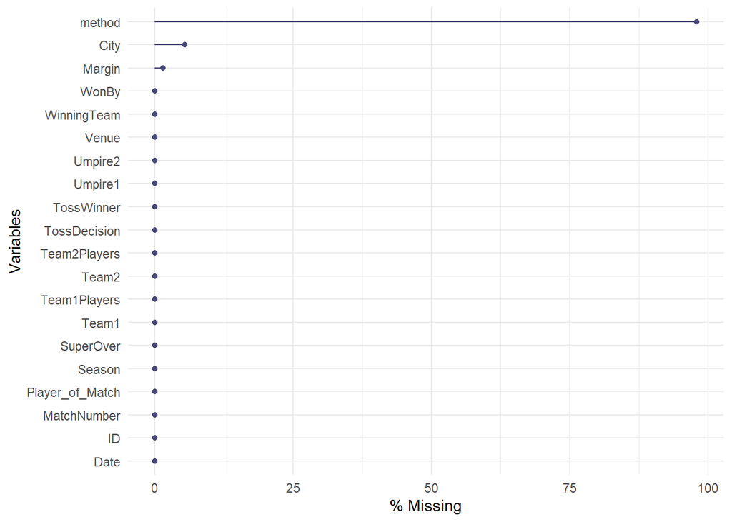

```r
# Missing values in specific columns
gg_miss_var(matches, show_pct = TRUE)
```

Summary Statistics and Distribution

```r
# Summary statistics
summary(deliveries)
```

```
##        ID             innings          overs          ballnumber
##  Min.   : 335982   Min.   :1.000   Min.   : 0.000   Min.   : 1.00
##  1st Qu.: 501262   1st Qu.:1.000   1st Qu.: 4.000   1st Qu.: 2.00
##  Median : 829737   Median :1.000   Median : 9.000   Median : 4.00
##  Mean   : 832047   Mean   :1.484   Mean   : 9.186   Mean   : 3.62
##  3rd Qu.:1178395   3rd Qu.:2.000   3rd Qu.:14.000   3rd Qu.: 5.00
##  Max.   :1312200   Max.   :6.000   Max.   :19.000   Max.   :10.00
##     batter             bowler          non-striker         extra_type
##  Length:225954      Length:225954      Length:225954      Length:225954
##  Class :character   Class :character   Class :character   Class :character
##  Mode  :character   Mode  :character   Mode  :character   Mode  :character
##
##
##
##   batsman_run      extras_run        total_run     non_boundary
##  Min.   :0.000   Min.   :0.00000   Min.   :0.00   Min.   :0.00e+00
##  1st Qu.:0.000   1st Qu.:0.00000   1st Qu.:0.00   1st Qu.:0.00e+00
##  Median :1.000   Median :0.00000   Median :1.00   Median :0.00e+00
##  Mean   :1.244   Mean   :0.06691   Mean   :1.31   Mean   :9.29e-05
##  3rd Qu.:1.000   3rd Qu.:0.00000   3rd Qu.:1.00   3rd Qu.:0.00e+00
##  Max.   :6.000   Max.   :7.00000   Max.   :7.00   Max.   :1.00e+00
##  isWicketDelivery   player_out            kind           fielders_involved
##  Min.   :0.00000   Length:225954      Length:225954      Length:225954
##  1st Qu.:0.00000   Class :character   Class :character   Class :character
##  Median :0.00000   Mode  :character   Mode  :character   Mode  :character
##  Mean   :0.04935
##  3rd Qu.:0.00000
##  Max.   :1.00000
##  BattingTeam
##  Length:225954
##  Class :character
##  Mode  :character
##
##
##
```

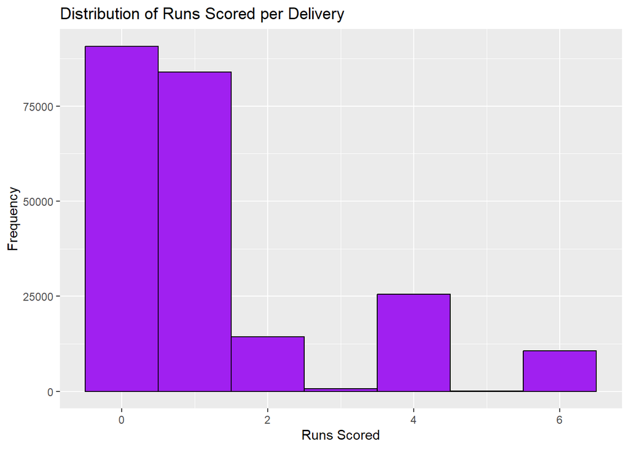

```r
# Distribution of runs scored per delivery
ggplot(deliveries, aes(x = batsman_run)) +
  geom_histogram(binwidth = 1, fill = 'purple', color = 'black') +
  labs(title = 'Distribution of Runs Scored per Delivery', x = 'Runs Scored', y = 'Frequency')
```

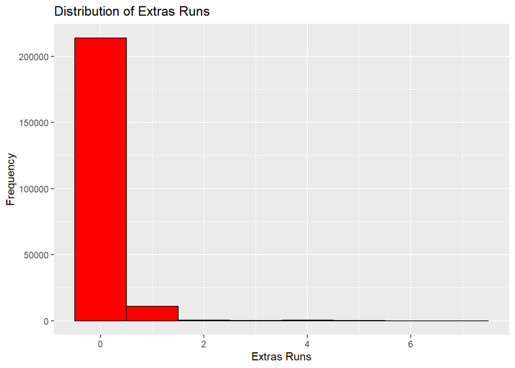

```r
# Distribution of extras runs
ggplot(deliveries, aes(x = extras_run)) +
  geom_histogram(binwidth = 1, fill = 'red', color = 'black') +
  labs(title = 'Distribution of Extras Runs', x = 'Extras Runs', y = 'Frequency')
```

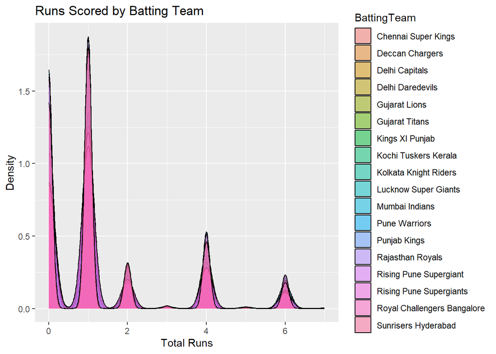

```r
# Runs scored by batting team
ggplot(deliveries, aes(x = total_run, fill = BattingTeam)) +
  geom_density(alpha = 0.5) +
  labs(title = 'Runs Scored by Batting Team', x = 'Total Runs', y = 'Density')
```

`Distribution of Runs Scored per Delivery:` The histogram shows that the majority of deliveries result in 0 or 1 run, indicating that dot balls and singles are the most common outcomes in the IPL matches. Higher scores per delivery, such as 4s and 6s, occur less frequently but are crucial for increasing the total score.

`Distribution of Extras Runs:` The histogram reveals that most deliveries do not result in any extra runs, with a significant drop in frequency for deliveries resulting in 1 or more extra runs. This indicates that bowlers generally maintain good discipline and control, minimizing the occurrence of wides, no-balls, and other extras.

Match Outcomes Analysis

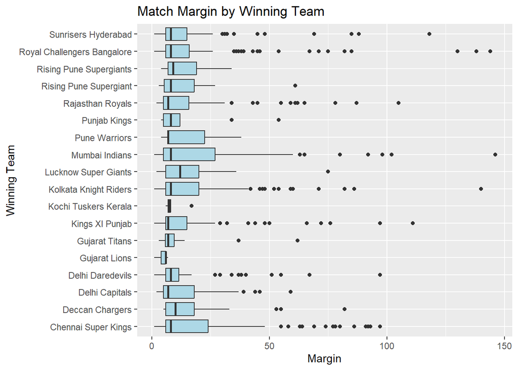

```r
# Win margin by team
ggplot(matches, aes(x = WinningTeam, y = Margin)) +
  geom_boxplot(fill = 'lightblue') +
  coord_flip() +
  labs(title = 'Match Margin by Winning Team', x = 'Winning Team', y = 'Margin')
```

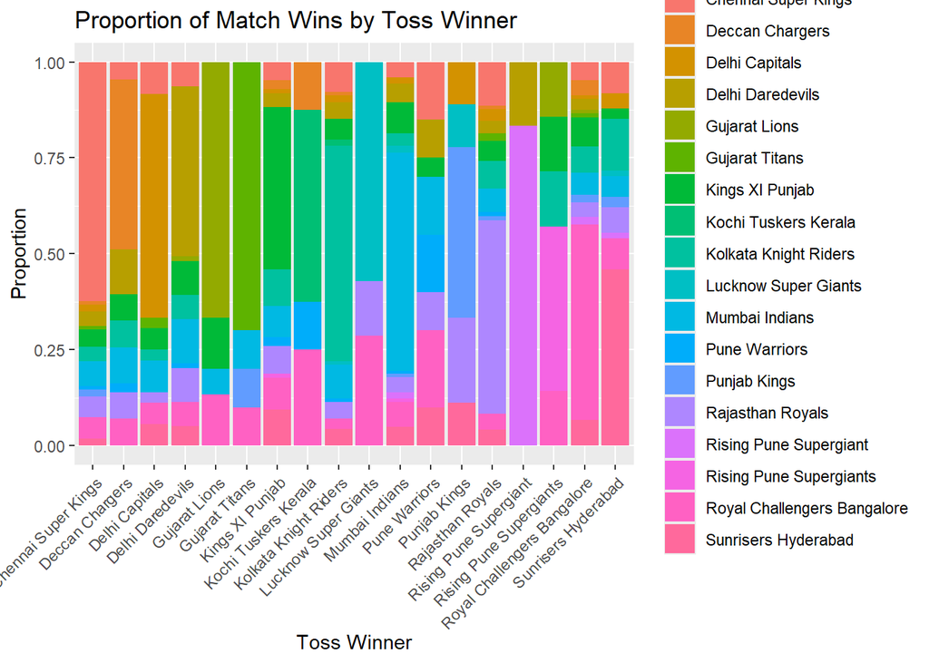

```r
# Toss winners vs. match winners
ggplot(matches, aes(x = TossWinner, fill = WinningTeam)) +
  geom_bar(position = 'fill') +
  labs(title = 'Proportion of Match Wins by Toss Winner', x = 'Toss Winner', y = 'Proportion')+
  theme(axis.text.x = element_text(angle = 45, hjust = 1))
```

Time-Based Trends

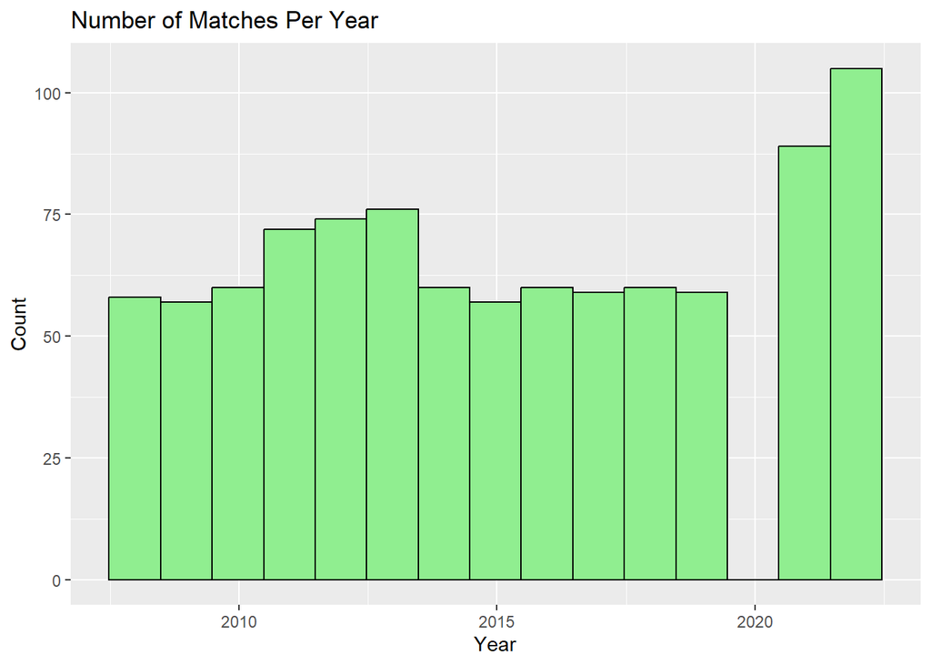

```r
# Number of matches over the years
ggplot(matches, aes(x = Date)) +
  geom_histogram(binwidth = 365, fill = 'lightgreen', color = 'black') +
  labs(title = 'Number of Matches Per Year', x = 'Year', y = 'Count')
```

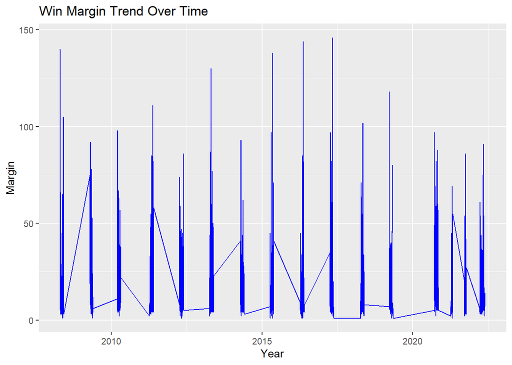

```r
# Win margins over the years
ggplot(matches, aes(x = Date, y = Margin)) +
  geom_line(color = 'blue') +
  labs(title = 'Win Margin Trend Over Time', x = 'Year', y = 'Margin')
```

`Win Margin Trend Over Time:` The line graph indicates a consistent trend in win margins over the years, with no significant increase or decrease, suggesting stable competitiveness in the matches.

Team Performance Analysis

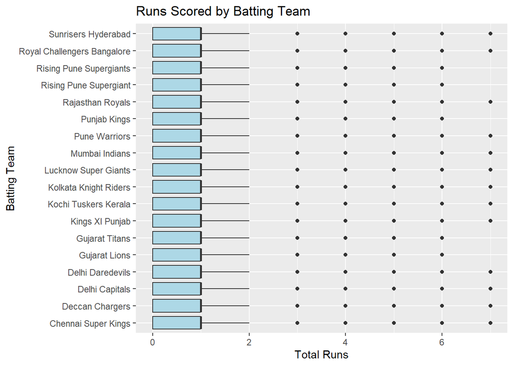

```r
# Runs scored by team
ggplot(deliveries, aes(x = BattingTeam, y = total_run)) +
  geom_boxplot(fill = 'lightblue') +
  coord_flip() +
  labs(title = 'Runs Scored by Batting Team', x = 'Batting Team', y = 'Total Runs')
```

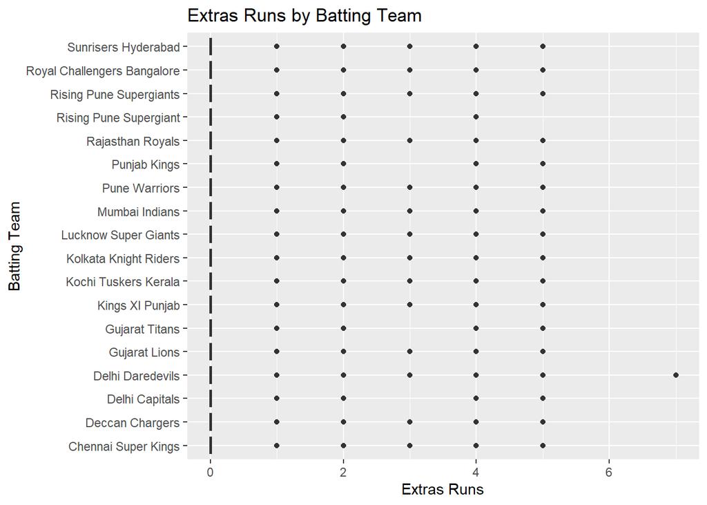

```r
# Extras runs by team
ggplot(deliveries, aes(x = BattingTeam, y = extras_run)) +
  geom_boxplot(fill = 'lightcoral') +
  coord_flip() +
  labs(title = 'Extras Runs by Batting Team', x = 'Batting Team', y = 'Extras Runs')
```

```r
bowler_stats <- deliveries |>
  group_by(bowler) |>
  summarise(total_runs_conceded = sum(total_run)) |>
  arrange(desc(total_runs_conceded))

# Select top 10 bowlers
top_10_bowlers <- head(bowler_stats, 10)
```

[figure not shown]

```r
# Performance metrics by bowler
ggplot(top_10_bowlers, aes(x = bowler, y = total_runs_conceded)) +
  geom_boxplot(fill = 'lightgreen') +
  coord_flip() +
  labs(title = 'Runs Conceded by Bowler', x = 'Bowler', y = 'Total Runs Conceded') +
  theme(axis.text.y = element_text(size = 3, angle = 45, hjust = 1)) +
  theme(plot.title = element_text(hjust = 0.5))
```

### 5. Simple Linear Regression

To begin, we will apply a simple linear regression model to analyze the relationship between the total number of runs scored and the total number of balls faced. This method will help us understand how the number of balls faced influences the total runs scored by a player.

```r
model_slr <- lm(Runs_Scored ~ Balls_Faced, data = batter_stats)
```

Plotting the fitted line for the model

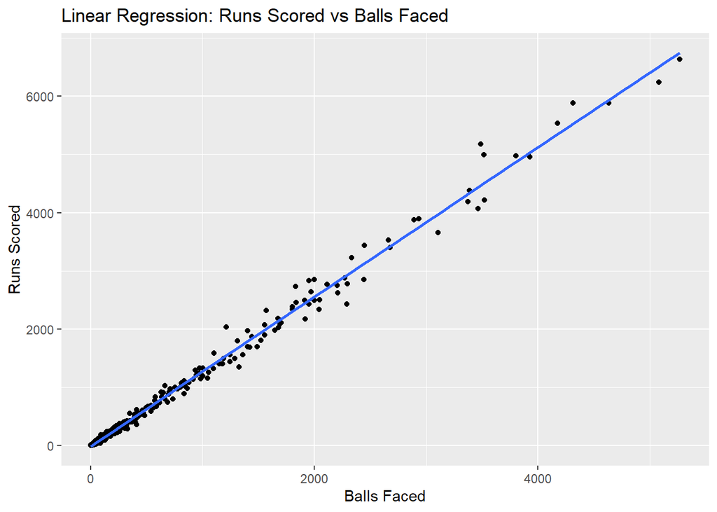

```r
ggplot(batter_stats, aes(x = Balls_Faced, y = Runs_Scored)) +
  geom_point() +
  geom_smooth(method = "lm", se = FALSE) +
  labs(title = "Linear Regression: Runs Scored vs Balls Faced",
       x = "Balls Faced",
       y = "Runs Scored")
```

```r
summary(model_slr)
```

```
##
## Call:
## lm(formula = Runs_Scored ~ Balls_Faced, data = batter_stats)
##
## Residuals:
##     Min      1Q  Median      3Q     Max
## -500.62  -15.19    4.92   14.05  717.03
##
## Coefficients:
##               Estimate Std. Error t value Pr(>|t|)
## (Intercept) -15.331011   3.651557  -4.198 3.09e-05 ***
## Balls_Faced   1.284572   0.004295 299.097  < 2e-16 ***
## ---
## Signif. codes:  0 '***' 0.001 '**' 0.01 '*' 0.05 '.' 0.1 ' ' 1
##
## Residual standard error: 80.69 on 603 degrees of freedom
## Multiple R-squared:  0.9933, Adjusted R-squared:  0.9933
## F-statistic: 8.946e+04 on 1 and 603 DF,  p-value: < 2.2e-16
```

The coefficient for balls faced is 1.28, indicating a highly significant relationship and this suggests that each additional ball faced results in an increase of approximately 1.28 runs. The simplified model, using only the balls faced predictor, explains 99.33% of the variability in the runs scored.

The regression analysis demonstrates a strong positive correlation between the number of balls faced and the runs scored by batters. The high R-squared value indicates that the model explains most of the variability in the data. This model can be useful for predicting a batter’s potential runs based on the number of balls they are expected to face.

#### Cross Validation for the Simple Linear Regression

To ensure robust and reliable analysis, the dataset was divided into training and testing subsets. This division helps in building a predictive model on one subset and validating its performance on another, thereby avoiding overfitting and ensuring the model generalizes well to unseen data with 80% data is training data and remaining 20% data will go into test data.

```r
set.seed(1994)
split_data <- initial_split(batter_stats, prop = 0.80)
train_data <- training(split_data)
test_data <- testing(split_data)
```

```r
# Train the linear regression model with cross-validation
model_slr <- train(Runs_Scored ~ Balls_Faced, data = train_data, method = "lm")
```

```r
# Print the model details
summary(model_slr)
```

```
##
## Call:
## lm(formula = .outcome ~ ., data = dat)
##
## Residuals:
##     Min      1Q  Median      3Q     Max
## -495.88  -16.58    5.61   14.83  502.64
##
## Coefficients:
##               Estimate Std. Error t value Pr(>|t|)
## (Intercept) -16.109238   3.921410  -4.108 4.69e-05 ***
## Balls_Faced   1.282841   0.004733 271.017  < 2e-16 ***
## ---
## Signif. codes:  0 '***' 0.001 '**' 0.01 '*' 0.05 '.' 0.1 ' ' 1
##
## Residual standard error: 77.18 on 482 degrees of freedom
## Multiple R-squared:  0.9935, Adjusted R-squared:  0.9935
## F-statistic: 7.345e+04 on 1 and 482 DF,  p-value: < 2.2e-16
```

These findings highlight a strong positive correlation between the number of balls faced and the runs scored, demonstrating the effectiveness of using balls faced as a predictor for runs scored in cricket. This model can be a valuable tool for predicting a batter’s performance and guiding strategic decisions in cricket.

### 6. Multiple Linear regression

To develop a multiple regression model to predict the Runs_Scored by a batter based on key performance metrics: `Balls_Faced`, `Highest_Score`, `Batting_Strike_Rate`, and `Batting_Average`. By incorporating multiple predictors, we aim to enhance the accuracy and reliability of the prediction model, providing deeper insights into factors influencing a batter’s performance.

```r
model_mlr <- lm(Runs_Scored ~ Balls_Faced + Highest_Score + Batting_Strike_Rate + Batting_Average, data = batter_stats)
```

```r
summary(model_mlr)
```

```
##
## Call:
## lm(formula = Runs_Scored ~ Balls_Faced + Highest_Score + Batting_Strike_Rate +
##     Batting_Average, data = batter_stats)
##
## Residuals:
##     Min      1Q  Median      3Q     Max
## -492.23  -16.61    4.93   17.96  717.47
##
## Coefficients:
##                      Estimate Std. Error t value Pr(>|t|)
## (Intercept)         -46.82031    8.86581  -5.281  1.8e-07 ***
## Balls_Faced           1.27643    0.00652 195.782  < 2e-16 ***
## Highest_Score         0.10804    0.16472   0.656  0.51214
## Batting_Strike_Rate   0.30330    0.09664   3.139  0.00178 **
## Batting_Average      11.34659   28.15158   0.403  0.68705
## ---
## Signif. codes:  0 '***' 0.001 '**' 0.01 '*' 0.05 '.' 0.1 ' ' 1
##
## Residual standard error: 79.84 on 600 degrees of freedom
## Multiple R-squared:  0.9935, Adjusted R-squared:  0.9934
## F-statistic: 2.285e+04 on 4 and 600 DF,  p-value: < 2.2e-16
```

The linear regression model fits the data well, with an R-squared value of 0.9935, indicating that 99.35% of the variability in `Runs_Scored` is explained by the predictors. Significant predictors are `Balls_Faced` and `Batting_Strike_Rate`, while `Highest_Score` and `Batting_Average` are not. The model is statistically significant overall

Creating a matrix of scatterplots to examinine the relationships among `Runs_Scored`, `Balls_Faced`, `Highest_Score`, `Batting_Strike_Rate`, and `Batting_Average`.

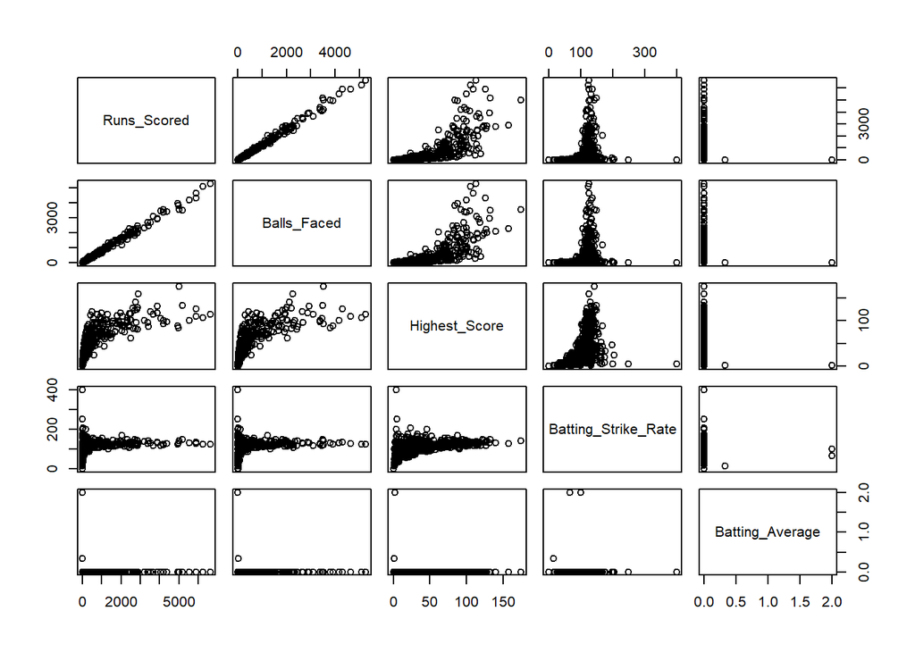

```r
pairs(batter_stats[, c("Runs_Scored", "Balls_Faced", "Highest_Score", "Batting_Strike_Rate", "Batting_Average")])
```

Plotting to all independent variables to understand linear model fitting

Balls_Faced v/s Runs_Scored:

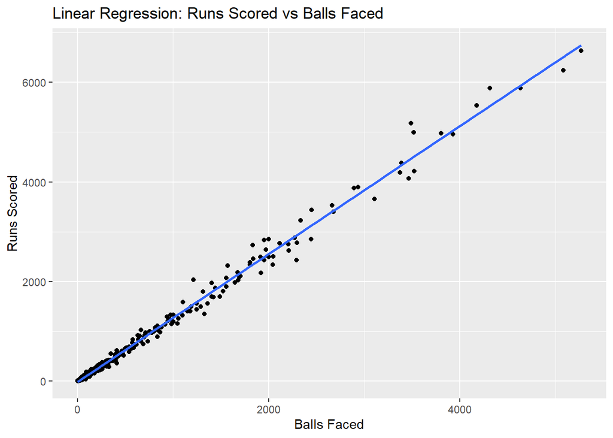

```r
ggplot(batter_stats, aes(x = Balls_Faced, y = Runs_Scored)) +
  geom_point() +
  geom_smooth(method = "lm", se = FALSE) +
  labs(title = "Linear Regression: Runs Scored vs Balls Faced",
       x = "Balls Faced",
       y = "Runs Scored")
```

Highest_Score v/s Runs_Scored:

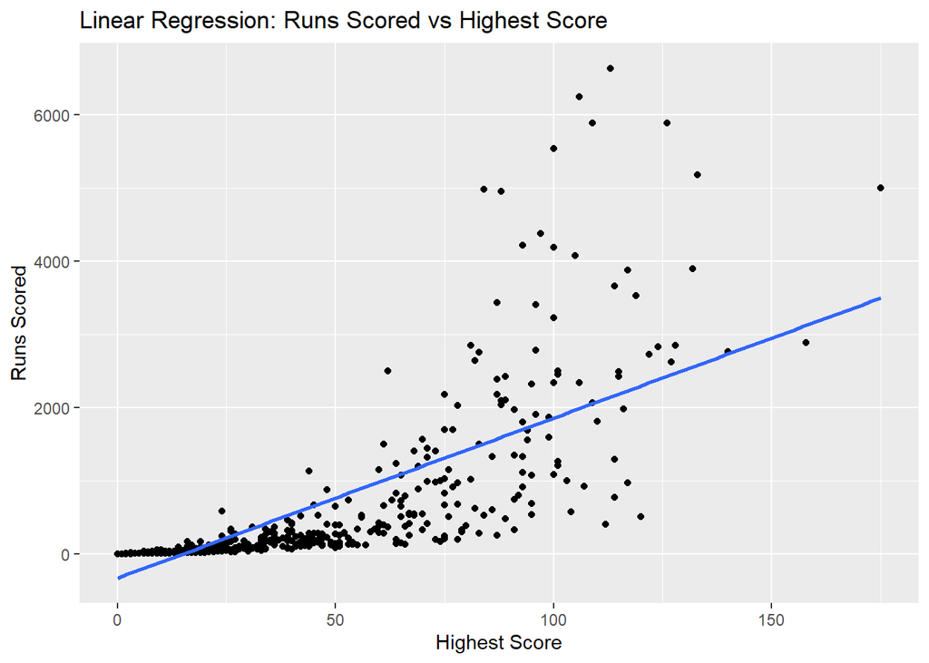

```r
ggplot(batter_stats, aes(x = Highest_Score, y = Runs_Scored)) +
  geom_point() +
  geom_smooth(method = "lm", se = FALSE) +
  labs(title = "Linear Regression: Runs Scored vs Highest Score",
       x = "Highest Score",
       y = "Runs Scored")
```

Batting_Strike_Rate v/s Runs_Scored:

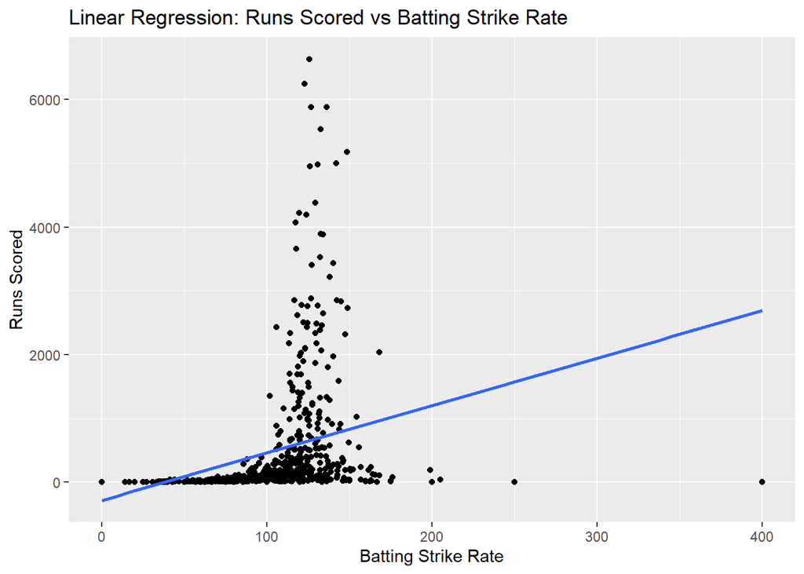

```r
ggplot(batter_stats, aes(x = Batting_Strike_Rate, y = Runs_Scored)) +
  geom_point() +
  geom_smooth(method = "lm", se = FALSE) +
  labs(title = "Linear Regression: Runs Scored vs Batting Strike Rate",
       x = "Batting Strike Rate",
       y = "Runs Scored")
```

Batting_Average v/s Runs_Scored:

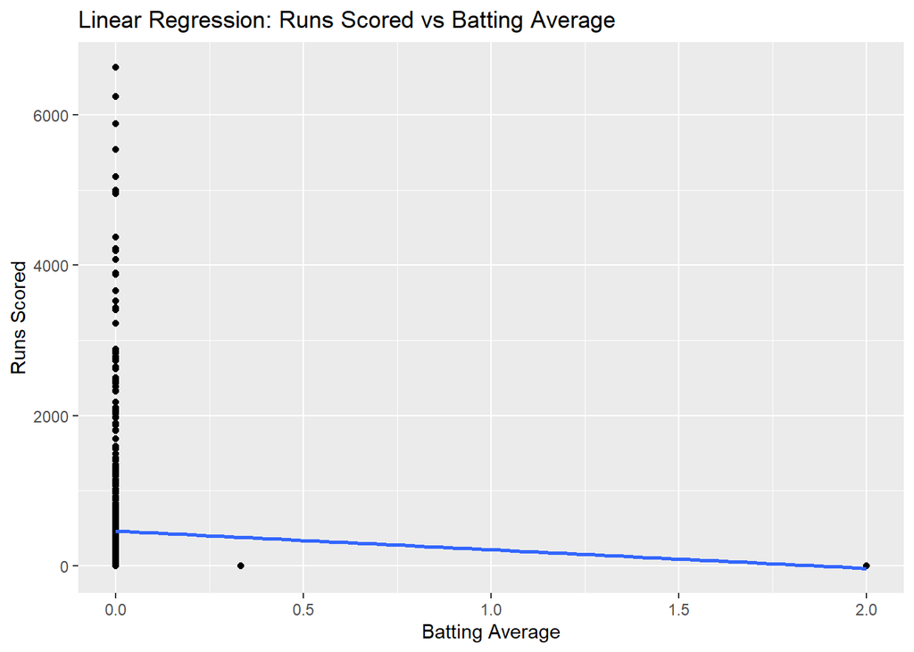

```r
ggplot(batter_stats, aes(x = Batting_Average, y = Runs_Scored)) +
  geom_point() +
  geom_smooth(method = "lm", se = FALSE) +
  labs(title = "Linear Regression: Runs Scored vs Batting Average",
       x = "Batting Average",
       y = "Runs Scored")
```

Plotting Residuals v/s Fitted Values

```r
train_aug <- augment(model_mlr, new_data = batter_stats)
head(train_aug)
```

```
## # A tibble: 6 × 11
##   Runs_Scored Balls_Faced Highest_Score Batting_Strike_Rate Batting_Average
##         <dbl>       <int>         <dbl>               <dbl>           <dbl>
## 1         280         196            36               143.                0
## 2         161         139            54               116.                0
## 3           4           7             4                57.1               0
## 4          53          75            24                70.7               0
## 5          25          20            15               125                 0
## 6           4           5             4                80                 0
## # ℹ 6 more variables: .fitted <dbl>, .resid <dbl>, .hat <dbl>, .sigma <dbl>,
## #   .cooksd <dbl>, .std.resid <dbl>
```

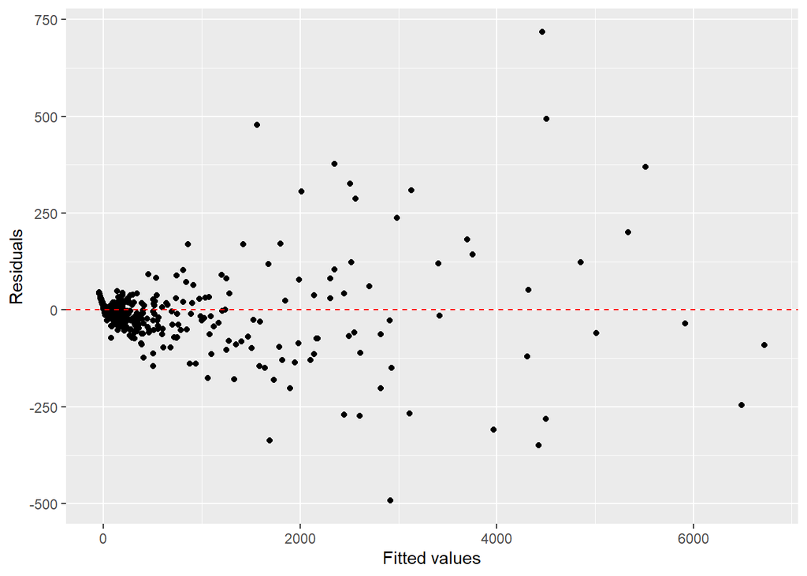

```r
ggplot(data = train_aug, aes(x = .fitted, y = .resid)) +
  geom_point() +
  geom_hline(yintercept = 0, linetype = "dashed", color = "red") +
  xlab("Fitted values") +
  ylab("Residuals")
```

The model captures some underlying patterns in the data, offering a good starting point for refining the relationship between predictors and the response variable.

#### Cross Validations for Multiple Linear Regression

Here I will be using Training and Test data split which I have used in Simple linear Regression Model

```r
# Train the linear regression model with cross-validation
model_mlr <- train(Runs_Scored ~ Balls_Faced + Highest_Score + Batting_Strike_Rate + Batting_Average, data = train_data, method = "lm")
```

```r
# Print the model details
summary(model_mlr)
```

```
##
## Call:
## lm(formula = .outcome ~ ., data = dat)
##
## Residuals:
##     Min      1Q  Median      3Q     Max
## -486.58  -19.86    5.65   19.32  498.72
##
## Coefficients:
##                       Estimate Std. Error t value Pr(>|t|)
## (Intercept)         -47.694391   9.382291  -5.083 5.33e-07 ***
## Balls_Faced           1.272223   0.007079 179.710  < 2e-16 ***
## Highest_Score         0.185381   0.175187   1.058  0.29050
## Batting_Strike_Rate   0.284214   0.102188   2.781  0.00563 **
## Batting_Average      12.536124  26.907277   0.466  0.64150
## ---
## Signif. codes:  0 '***' 0.001 '**' 0.01 '*' 0.05 '.' 0.1 ' ' 1
##
## Residual standard error: 76.22 on 479 degrees of freedom
## Multiple R-squared:  0.9937, Adjusted R-squared:  0.9936
## F-statistic: 1.883e+04 on 4 and 479 DF,  p-value: < 2.2e-16
```

### 7. Logistic Regression

To prepare our data for a logistic regression analysis, we added a ‘winner’ column with binary values (0 and 1) to indicate the outcome of interest. This allows us to train the logistic regression model, which is ideal for predicting binary outcomes based on predictor variables. By using logistic regression, we can analyze the relationship between the predictors and the likelihood of winning, providing insights into the factors that influence the probability of success.

```r
new_ipl_data <- matches |>
  gather(key = "TeamType", value = "Team", Team1, Team2) |>
  mutate(Winner = ifelse(Team == matches$WinningTeam, 1, 0)) |>
  mutate(Toss_Y_N = ifelse(Team == TossWinner, 1, 0)) |>
  select(-TeamType) |> arrange(ID)
```

```r
head(new_ipl_data)
```

```
## # A tibble: 6 × 21
##       ID City       Date       Season  MatchNumber Venue TossWinner TossDecision
##    <dbl> <chr>      <date>     <chr>   <chr>       <chr> <chr>      <chr>
## 1 335982 Bangalore  2008-04-18 2007/08 1           M Ch… Royal Cha… field
## 2 335982 Bangalore  2008-04-18 2007/08 1           M Ch… Royal Cha… field
## 3 335983 Chandigarh 2008-04-19 2007/08 2           Punj… Chennai S… bat
## 4 335983 Chandigarh 2008-04-19 2007/08 2           Punj… Chennai S… bat
## 5 335984 Delhi      2008-04-19 2007/08 3           Fero… Rajasthan… bat
## 6 335984 Delhi      2008-04-19 2007/08 3           Fero… Rajasthan… bat
## # ℹ 13 more variables: SuperOver <chr>, WinningTeam <chr>, WonBy <chr>,
## #   Margin <dbl>, method <chr>, Player_of_Match <chr>, Team1Players <chr>,
## #   Team2Players <chr>, Umpire1 <chr>, Umpire2 <chr>, Team <chr>, Winner <dbl>,
## #   Toss_Y_N <dbl>
```

Converting new variables into factor variables

```r
new_ipl_data$Winner <- as.factor(new_ipl_data$Winner)
new_ipl_data$Toss_Y_N <- as.factor(new_ipl_data$Toss_Y_N)
new_ipl_data
```

```
## # A tibble: 1,892 × 21
##        ID City       Date       Season MatchNumber Venue TossWinner TossDecision
##     <dbl> <chr>      <date>     <chr>  <chr>       <chr> <chr>      <chr>
##  1 335982 Bangalore  2008-04-18 2007/… 1           M Ch… Royal Cha… field
##  2 335982 Bangalore  2008-04-18 2007/… 1           M Ch… Royal Cha… field
##  3 335983 Chandigarh 2008-04-19 2007/… 2           Punj… Chennai S… bat
##  4 335983 Chandigarh 2008-04-19 2007/… 2           Punj… Chennai S… bat
##  5 335984 Delhi      2008-04-19 2007/… 3           Fero… Rajasthan… bat
##  6 335984 Delhi      2008-04-19 2007/… 3           Fero… Rajasthan… bat
##  7 335985 Mumbai     2008-04-20 2007/… 5           Wank… Mumbai In… bat
##  8 335985 Mumbai     2008-04-20 2007/… 5           Wank… Mumbai In… bat
##  9 335986 Kolkata    2008-04-20 2007/… 4           Eden… Deccan Ch… bat
## 10 335986 Kolkata    2008-04-20 2007/… 4           Eden… Deccan Ch… bat
## # ℹ 1,882 more rows
## # ℹ 13 more variables: SuperOver <chr>, WinningTeam <chr>, WonBy <chr>,
## #   Margin <dbl>, method <chr>, Player_of_Match <chr>, Team1Players <chr>,
## #   Team2Players <chr>, Umpire1 <chr>, Umpire2 <chr>, Team <chr>, Winner <fct>,
## #   Toss_Y_N <fct>
```

Checking some samples of data

```r
head(new_ipl_data |> select(ID,Team,WinningTeam,Winner))
```

```
## # A tibble: 6 × 4
##       ID Team                        WinningTeam           Winner
##    <dbl> <chr>                       <chr>                 <fct>
## 1 335982 Royal Challengers Bangalore Kolkata Knight Riders 0
## 2 335982 Kolkata Knight Riders       Kolkata Knight Riders 1
## 3 335983 Kings XI Punjab             Chennai Super Kings   0
## 4 335983 Chennai Super Kings         Chennai Super Kings   1
## 5 335984 Delhi Daredevils            Delhi Daredevils      1
## 6 335984 Rajasthan Royals            Delhi Daredevils      0
```

Aggregating the deliveries data to calculate the total runs and total extras, so that we will join data with original match data

```r
deliveries_grouped_data <- deliveries |>
  group_by(ID,BattingTeam) |>
  summarise(
    total_extras = sum(extras_run),
    total_runs = sum(batsman_run)
  )
```

Checking sample of data

```r
head(deliveries_grouped_data)
```

```
## # A tibble: 6 × 4
## # Groups:   ID [3]
##       ID BattingTeam                 total_extras total_runs
##    <dbl> <chr>                              <dbl>      <dbl>
## 1 335982 Kolkata Knight Riders                 17        205
## 2 335982 Royal Challengers Bangalore           19         63
## 3 335983 Chennai Super Kings                    6        234
## 4 335983 Kings XI Punjab                       11        196
## 5 335984 Delhi Daredevils                      10        122
## 6 335984 Rajasthan Royals                       7        122
```

Now joining with the original match data

```r
joined_data <- deliveries_grouped_data |>
  inner_join(new_ipl_data, by = c("ID" = "ID","BattingTeam" = "Team"))
head(joined_data)
```

```
## # A tibble: 6 × 23
## # Groups:   ID [3]
##       ID BattingTeam total_extras total_runs City  Date       Season MatchNumber
##    <dbl> <chr>              <dbl>      <dbl> <chr> <date>     <chr>  <chr>
## 1 335982 Kolkata Kn…           17        205 Bang… 2008-04-18 2007/… 1
## 2 335982 Royal Chal…           19         63 Bang… 2008-04-18 2007/… 1
## 3 335983 Chennai Su…            6        234 Chan… 2008-04-19 2007/… 2
## 4 335983 Kings XI P…           11        196 Chan… 2008-04-19 2007/… 2
## 5 335984 Delhi Dare…           10        122 Delhi 2008-04-19 2007/… 3
## 6 335984 Rajasthan …            7        122 Delhi 2008-04-19 2007/… 3
## # ℹ 15 more variables: Venue <chr>, TossWinner <chr>, TossDecision <chr>,
## #   SuperOver <chr>, WinningTeam <chr>, WonBy <chr>, Margin <dbl>,
## #   method <chr>, Player_of_Match <chr>, Team1Players <chr>,
## #   Team2Players <chr>, Umpire1 <chr>, Umpire2 <chr>, Winner <fct>,
## #   Toss_Y_N <fct>
```

Applying Logistic regression model

```r
logistic_spec <- logistic_reg() %>%
  set_engine("glm")



cric_mod <- logistic_spec %>%
  fit(Winner ~  total_runs, data = joined_data, family = "binomial")

tidy(cric_mod) %>%
  knitr::kable(digits = 3)
```

| term | estimate | std.error | statistic | p.value |
| --- | --- | --- | --- | --- |
| (Intercept) | -2.405 | 0.251 | -9.562 | 0 |
| total_runs | 0.016 | 0.002 | 9.751 | 0 |

The estimate for total_runs is 0.016, with a standard error of 0.002, and is statistically significant with a p-value of 0. This indicates that for each additional run, the log-odds of the outcome increases by 0.016.

The Bayesian Information Criterion (BIC) :

```r
BIC(cric_mod$fit)
```

```
## [1] 2534.014
```

The Akaike Information Criterion (AIC) :

```r
AIC(cric_mod$fit)
```

```
## [1] 2522.924
```

looks like total_runs is statistically significant to our test

```r
logistic_spec <- logistic_reg() %>%
  set_engine("glm")



cric_mod <- logistic_spec %>%
  fit(Winner ~ total_runs + Toss_Y_N, data = joined_data, family = "binomial")

tidy(cric_mod) %>%
  knitr::kable(digits = 3)
```

| term | estimate | std.error | statistic | p.value |
| --- | --- | --- | --- | --- |
| (Intercept) | -2.542 | 0.260 | -9.762 | 0.000 |
| total_runs | 0.016 | 0.002 | 9.858 | 0.000 |
| Toss_Y_N1 | 0.203 | 0.095 | 2.142 | 0.032 |

The coefficient for Toss_Y_N1 is 0.203, if the toss result is 1 , the log-odds of the outcome increase by 0.203. This predictor is also significant (p < 0.05), suggesting that winning the toss has a positive impact on the likelihood of the outcome.

The Bayesian Information Criterion (BIC) :

```r
BIC(cric_mod$fit)
```

```
## [1] 2536.962
```

The Akaike Information Criterion (AIC) :

```r
AIC(cric_mod$fit)
```

```
## [1] 2520.326
```

```r
pred_data <- predict(cric_mod, new_data = joined_data, type = "prob")$.pred__1
pred_data_1 <- data.frame(pred_data)
```

```r
mult_log_aug <- augment(cric_mod$fit, new_data = joined_data, type.predict = "response", type.residuals = "deviance") |>
  mutate(id = row_number())
```

```r
head(mult_log_aug)
```

```
## # A tibble: 6 × 10
##   Winner total_runs Toss_Y_N .fitted .resid    .hat .sigma  .cooksd .std.resid
##   <fct>       <dbl> <fct>      <dbl>  <dbl>   <dbl>  <dbl>    <dbl>      <dbl>
## 1 1             205 0          0.696  0.851 0.00268   1.15 0.000391      0.852
## 2 0              63 1          0.214 -0.694 0.00401   1.15 0.000366     -0.695
## 3 1             234 1          0.819  0.632 0.00382   1.15 0.000284      0.633
## 4 0             196 0          0.664 -1.48  0.00227   1.15 0.00150      -1.48
## 5 1             122 0          0.369  1.41  0.00158   1.15 0.000905      1.41
## 6 0             122 1          0.418 -1.04  0.00149   1.15 0.000358     -1.04
## # ℹ 1 more variable: id <int>
```

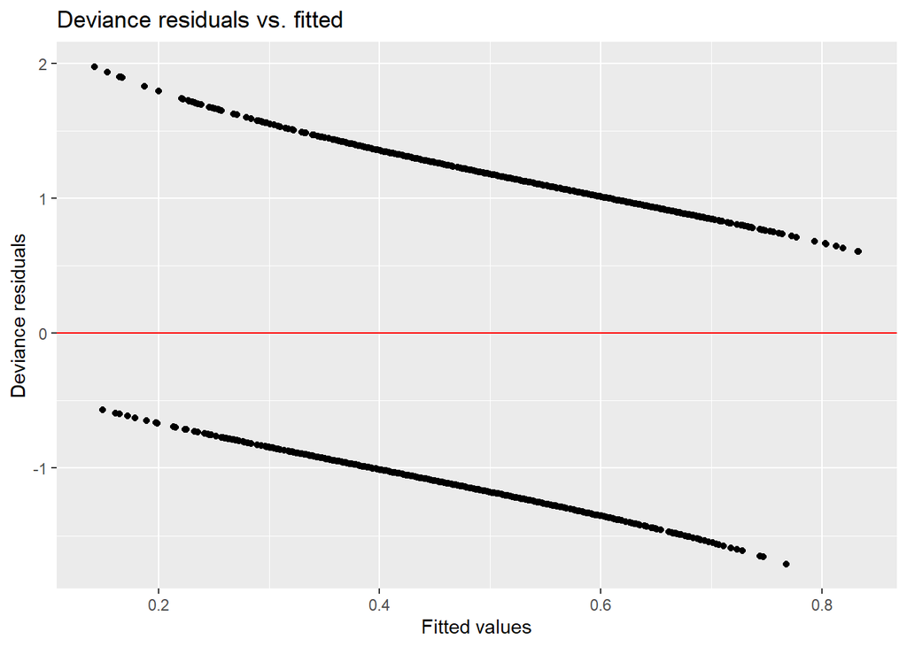

```r
# Plot residuals vs fitted values
ggplot(data = mult_log_aug, aes(x = .fitted, y = .resid)) +
geom_point() +
geom_hline(yintercept = 0, color = "red") +
labs(x = "Fitted values",
     y = "Deviance residuals",
     title = "Deviance residuals vs. fitted")
```

The Deviance Residuals vs Fitted Values plot for your logistic regression model shows the expected parallel bands, suggesting that the model captures the binary nature of the response variable.

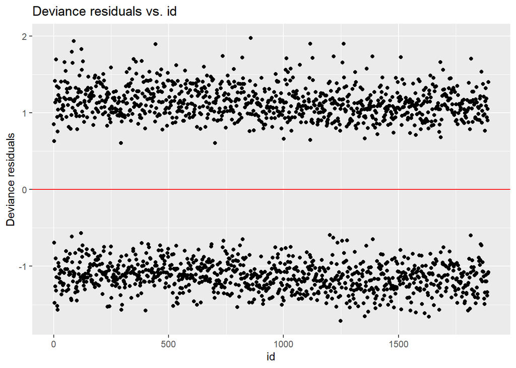

```r
# Plot residuals vs row number
ggplot(data = mult_log_aug, aes(x = id, y = .resid)) +
geom_point() +
geom_hline(yintercept = 0, color = "red") +
labs(x = "id",
     y = "Deviance residuals",
     title = "Deviance residuals vs. id")
```

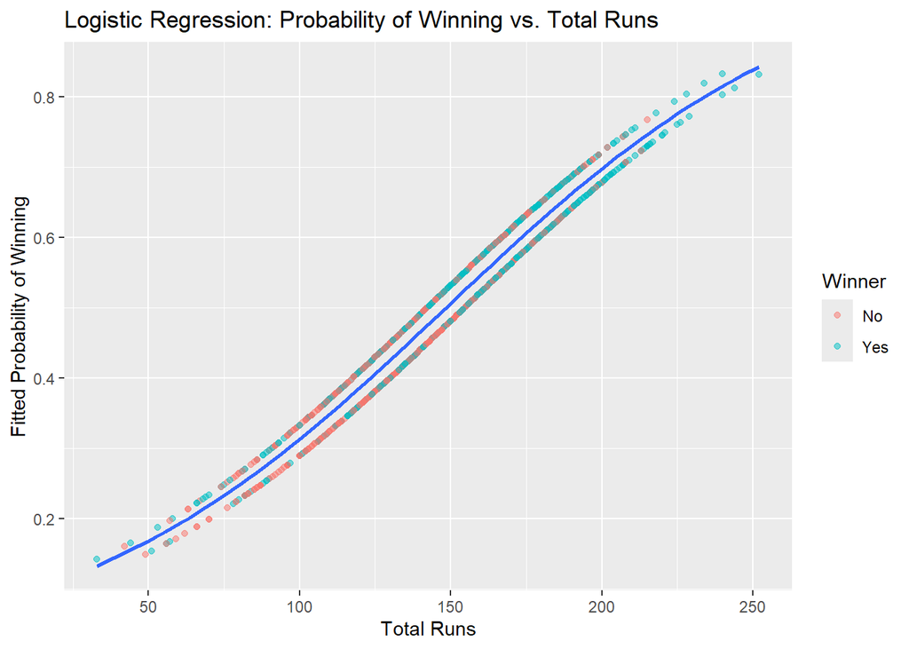

```r
ggplot(mult_log_aug, aes(x = total_runs, y = .fitted)) +
  geom_point(aes(color = as.factor(Winner)), alpha = 0.5) +
  geom_smooth(method = "glm", method.args = list(family = "binomial"), se = FALSE) +
  labs(title = "Logistic Regression: Probability of Winning vs. Total Runs",
       x = "Total Runs",
       y = "Fitted Probability of Winning") +
  scale_color_discrete(name = "Winner", labels = c("No", "Yes"))
```

#### Cross Validations Logistic regression for Model 1

```r
set.seed(1994)
split_data <- initial_split(joined_data, prop = 0.80)
train_data <- training(split_data)
test_data <- testing(split_data)
```

```r
head(train_data)
```

```
## # A tibble: 6 × 23
## # Groups:   ID [6]
##       ID BattingTeam total_extras total_runs City  Date       Season MatchNumber
##    <dbl> <chr>              <dbl>      <dbl> <chr> <date>     <chr>  <chr>
## 1 4.19e5 Royal Chal…           10        139 Mumb… 2010-04-21 2009/… Semi Final
## 2 3.36e5 Kolkata Kn…            9        166 Kolk… 2008-05-25 2007/… 52
## 3 1.14e6 Royal Chal…            4        172 Beng… 2018-04-21 2018   19
## 4 1.14e6 Delhi Dare…            8        121 Kolk… 2018-04-16 2018   13
## 5 1.08e6 Kings XI P…            2        135 Delhi 2017-04-15 2017   15
## 6 7.34e5 Mumbai Ind…            6        164 Mumb… 2014-05-03 2014   22
## # ℹ 15 more variables: Venue <chr>, TossWinner <chr>, TossDecision <chr>,
## #   SuperOver <chr>, WinningTeam <chr>, WonBy <chr>, Margin <dbl>,
## #   method <chr>, Player_of_Match <chr>, Team1Players <chr>,
## #   Team2Players <chr>, Umpire1 <chr>, Umpire2 <chr>, Winner <fct>,
## #   Toss_Y_N <fct>
```

```r
model <- train(Winner ~  total_runs, data = train_data, method = "glm", family = binomial())
```

```r
print(model)
```

```
## Generalized Linear Model
##
## 1513 samples
##    1 predictor
##    2 classes: '0', '1'
##
## No pre-processing
## Resampling: Bootstrapped (25 reps)
## Summary of sample sizes: 1513, 1513, 1513, 1513, 1513, 1513, ...
## Resampling results:
##
##   Accuracy   Kappa
##   0.6078421  0.2168024
```

```r
predictions <- predict(model, newdata = test_data)
head(predictions)
```

```
## [1] 0 0 0 0 0 0
## Levels: 0 1
```

```r
confusionMatrix(predictions, test_data$Winner)
```

```
## Confusion Matrix and Statistics
##
##           Reference
## Prediction   0   1
##          0 101  67
##          1  93 118
##
##                Accuracy : 0.5778
##                  95% CI : (0.5263, 0.6281)
##     No Information Rate : 0.5119
##     P-Value [Acc > NIR] : 0.005821
##
##                   Kappa : 0.1579
##
##  Mcnemar's Test P-Value : 0.048107
##
##             Sensitivity : 0.5206
##             Specificity : 0.6378
##          Pos Pred Value : 0.6012
##          Neg Pred Value : 0.5592
##              Prevalence : 0.5119
##          Detection Rate : 0.2665
##    Detection Prevalence : 0.4433
##       Balanced Accuracy : 0.5792
##
##        'Positive' Class : 0
##
```

Taking the wickets variable into account, as more wickets fall, matches are likely to become more pressured, significantly influencing the match-winning outcome.

```r
deliveries_grouped_data <- deliveries |>
  group_by(ID,BattingTeam) |>
  summarise(
    total_extras = sum(extras_run),
    total_runs = sum(batsman_run),
    total_wickets= sum(isWicketDelivery)
  )
```

```r
#str(deliveries_grouped_data)
```

```r
joined_data <- deliveries_grouped_data |>
  inner_join(new_ipl_data, by = c("ID" = "ID","BattingTeam" = "Team"))
head(joined_data)
```

```
## # A tibble: 6 × 24
## # Groups:   ID [3]
##       ID BattingTeam      total_extras total_runs total_wickets City  Date
##    <dbl> <chr>                   <dbl>      <dbl>         <dbl> <chr> <date>
## 1 335982 Kolkata Knight …           17        205             3 Bang… 2008-04-18
## 2 335982 Royal Challenge…           19         63            10 Bang… 2008-04-18
## 3 335983 Chennai Super K…            6        234             5 Chan… 2008-04-19
## 4 335983 Kings XI Punjab            11        196             4 Chan… 2008-04-19
## 5 335984 Delhi Daredevils           10        122             1 Delhi 2008-04-19
## 6 335984 Rajasthan Royals            7        122             8 Delhi 2008-04-19
## # ℹ 17 more variables: Season <chr>, MatchNumber <chr>, Venue <chr>,
## #   TossWinner <chr>, TossDecision <chr>, SuperOver <chr>, WinningTeam <chr>,
## #   WonBy <chr>, Margin <dbl>, method <chr>, Player_of_Match <chr>,
## #   Team1Players <chr>, Team2Players <chr>, Umpire1 <chr>, Umpire2 <chr>,
## #   Winner <fct>, Toss_Y_N <fct>
```

```r
joined_data$Winner <- as.factor(joined_data$Winner)
```

```r
logistic_spec <- logistic_reg() %>%
  set_engine("glm")



cric_mod <- logistic_spec %>%
  fit(Winner ~ total_runs + Toss_Y_N + total_wickets, data = joined_data, family = "binomial")

tidy(cric_mod) %>%
  knitr::kable(digits = 3)
```

| term | estimate | std.error | statistic | p.value |
| --- | --- | --- | --- | --- |
| (Intercept) | 1.730 | 0.372 | 4.646 | 0.000 |
| total_runs | 0.009 | 0.002 | 4.695 | 0.000 |
| Toss_Y_N1 | 0.122 | 0.111 | 1.101 | 0.271 |
| total_wickets | -0.547 | 0.028 | -19.495 | 0.000 |

The total_wickets variable is highly significant. The negative estimate suggests that as more wickets fall, the log-odds of the response variable decrease by 0.547 for each additional wicket. This implies that losing more wickets negatively impacts the probability of the response variable

The Bayesian Information Criterion (BIC) :

```r
BIC(cric_mod$fit)
```

```
## [1] 2006.379
```

The Akaike Information Criterion (AIC) :

```r
AIC(cric_mod$fit)
```

```
## [1] 1984.197
```

`Decreased AIC`: Indicates that the new model provides a better fit to the data compared to the previous model. The reduction in AIC suggests that the added predictor (total_wickets) improves the model’s explanatory power without excessively increasing complexity.

`Decreased BIC`: Also suggests an improvement in model quality, but with a stricter penalty for the number of predictors. A lower BIC reinforces the conclusion that the new model is preferable, balancing fit and simplicity more effectively than the previous model.

```r
mult_log_aug <- augment(cric_mod$fit, new_data = joined_data, type.predict = "response", type.residuals = "deviance") |>
  mutate(id = row_number())
```

#### Cross validations for the logistic regression Model 2

```r
set.seed(1994)
split_data <- initial_split(joined_data, prop = 0.80)
train_data <- training(split_data)
test_data <- testing(split_data)
```

```r
head(train_data)
```

```
## # A tibble: 6 × 24
## # Groups:   ID [6]
##        ID BattingTeam     total_extras total_runs total_wickets City  Date
##     <dbl> <chr>                  <dbl>      <dbl>         <dbl> <chr> <date>
## 1  419162 Royal Challeng…           10        139             9 Mumb… 2010-04-21
## 2  336035 Kolkata Knight…            9        166             7 Kolk… 2008-05-25
## 3 1136579 Royal Challeng…            4        172             4 Beng… 2018-04-21
## 4 1136573 Delhi Daredevi…            8        121            10 Kolk… 2018-04-16
## 5 1082605 Kings XI Punjab            2        135             9 Delhi 2017-04-15
## 6  733973 Mumbai Indians             6        164             5 Mumb… 2014-05-03
## # ℹ 17 more variables: Season <chr>, MatchNumber <chr>, Venue <chr>,
## #   TossWinner <chr>, TossDecision <chr>, SuperOver <chr>, WinningTeam <chr>,
## #   WonBy <chr>, Margin <dbl>, method <chr>, Player_of_Match <chr>,
## #   Team1Players <chr>, Team2Players <chr>, Umpire1 <chr>, Umpire2 <chr>,
## #   Winner <fct>, Toss_Y_N <fct>
```

```r
model_log_new <- train(Winner ~  total_runs + Toss_Y_N + total_wickets, data = train_data, method = "glm", family = binomial())
```

```r
print(model_log_new)
```

```
## Generalized Linear Model
##
## 1513 samples
##    3 predictor
##    2 classes: '0', '1'
##
## No pre-processing
## Resampling: Bootstrapped (25 reps)
## Summary of sample sizes: 1513, 1513, 1513, 1513, 1513, 1513, ...
## Resampling results:
##
##   Accuracy   Kappa
##   0.7388257  0.4772867
```

```r
predictions <- predict(model_log_new, newdata = test_data)
head(predictions)
```

```
## [1] 1 0 0 0 1 0
## Levels: 0 1
```

```r
confusionMatrix(predictions, test_data$Winner)
```

```
## Confusion Matrix and Statistics
##
##           Reference
## Prediction   0   1
##          0 144  45
##          1  50 140
##
##                Accuracy : 0.7493
##                  95% CI : (0.7025, 0.7922)
##     No Information Rate : 0.5119
##     P-Value [Acc > NIR] : <2e-16
##
##                   Kappa : 0.4987
##
##  Mcnemar's Test P-Value : 0.6815
##
##             Sensitivity : 0.7423
##             Specificity : 0.7568
##          Pos Pred Value : 0.7619
##          Neg Pred Value : 0.7368
##              Prevalence : 0.5119
##          Detection Rate : 0.3799
##    Detection Prevalence : 0.4987
##       Balanced Accuracy : 0.7495
##
##        'Positive' Class : 0
##
```

```r
mult_log_aug <- augment(cric_mod$fit, new_data = joined_data, type.predict = "response", type.residuals = "deviance") |>
  mutate(id = row_number())
```

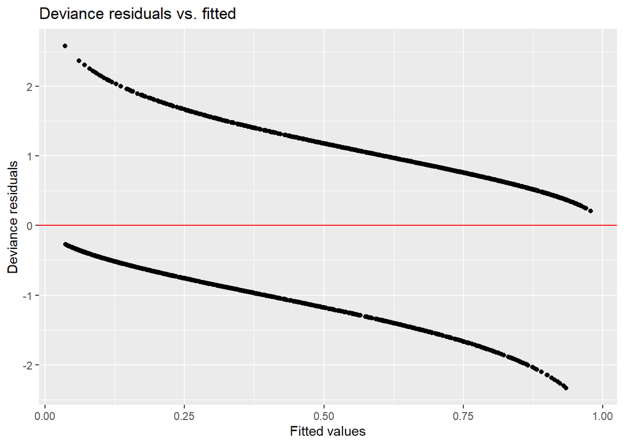

```r
# Plot residuals vs fitted values
ggplot(data = mult_log_aug, aes(x = .fitted, y = .resid)) +
geom_point() +
geom_hline(yintercept = 0, color = "red") +
labs(x = "Fitted values",
     y = "Deviance residuals",
     title = "Deviance residuals vs. fitted")
```

[figure not shown]

```r
ggplot(mult_log_aug, aes(x = total_wickets, y = .fitted)) +
  geom_point(aes(color = as.factor(Winner)), alpha = 0.5) +
  geom_smooth(method = "glm", method.args = list(family = "binomial"), se = FALSE) +
  labs(title = "Logistic Regression: Probability of Winning vs. Total Runs",
       x = "Total Wickets",
       y = "Fitted Probability of Winning") +
  scale_color_discrete(name = "Winner", labels = c("No", "Yes"))
```

The logistic regression model effectively captures the negative relationship between total wickets lost and the probability of winning. The model shows that as more wickets are lost, the likelihood of winning decreases

### 8. Conclusion

We Applied statistical and machine learning methods to analyze IPL match data. The logistic regression model achieving notable results with different models. The logistic regression model demonstrated an accuracy of 74.93%, with a sensitivity of 74.23% and a specificity of 75.68% . The simple linear regression model showed a strong positive correlation between runs scored and balls faced, with a coefficient of 1.28 and an R-squared value of 99.33%. The multiple linear regression model, including predictors such as highest score and batting strike rate, achieved an R-squared value of 0.9935. These models demonstrate the potential for using statistical techniques to gain insights and make predictions in sports analytics. Future work could involve integrating more advanced algorithms and additional data sources to enhance predictive accuracy.

### 9. Course Objectives Alignment

1.`Describe probability as a foundation of statistical modeling, including inference and maximum likelihood estimation` Probability serves as the foundation of statistical modeling in this IPL data analysis project. The project employs maximum likelihood estimation (MLE) to fit logistic regression models, where the probability of an event, such as winning a match, is modeled based on predictor variables like total runs, wickets taken, and whether a team won the toss. By using logistic regression, the project effectively captures relationships between these predictors and the probability of winning, illustrating the use of statistical inference in model building.

2.`Determine and apply the appropriate generalized linear model for a specific data context` Generalized Linear Models (GLMs) extend linear models to accommodate non-normal response distributions. In the project, a logistic regression model (a type of GLM) is applied to predict the binary outcome of match wins based on predictors such as total runs and whether a team won the toss. The logistic regression model is appropriate for binary outcomes and models the log-odds of the outcome as a linear combination of the predictors, providing insights into the relationship between the predictors and the probability of winning .

4.`Communicate the results of statistical models to a general audience` The project effectively communicates the results by explaining the significance of predictors, the model’s accuracy, and the implications of the findings. the project discusses how the number of runs scored is positively correlated with winning probability and provides visualizations like fitted probability curves to illustrate these relationships clearly to a general audience .

5.`Use programming software (i.e., R) to fit and assess statistical models` In this project, I used R to fit and assess statistical models by loading and preprocessing IPL data, splitting it into training and testing sets, and then applying machine learning algorithms to predict match outcomes. I utilized packages such as tidyverse for data manipulation, caret for model training and evaluation and These models were evaluated using appropriate performance metrics and visualized with ggplot2 to understand their behavior and effectiveness.